# CUNY SPS Data 607 Project 2

# Introduction

The goal of Project 2 is to choose 3 wide datasets and transform the datasets - Create a .CSV file (or optionally, a MySQL database!) that includes all of the information included in the dataset. You’re encouraged to use a “wide” structure similar to how the information appears in the discussion item, so that you can practice tidying and transformations as described below. - Read the information from your .CSV file into R, and use tidyr and dplyr as needed to tidy and transform your data. [Most of your grade will be based on this step!] - Perform the analysis requested in the discussion item. - Your codeshould be in an R Markdown file, posted to rpubs.com, and should include narrative descriptions of your data cleanup work, analysis,and conclusions.

# Dataset 1 : Canada Unemployment Rate

The dataset that is from Stat Canada which is a government organization which compiles data for the public. The dataset that we will be looking at is the Canada unemployment data (“Labour Force Characteristics, Monthly, Seasonally Adjusted and Trend-Cycle, Last 5 Months,” n.d.). We can see that this is a wide dataset with all of the months being in the columns. The CSV file also includes a lot of unnecessary information that needs to be cleaned before any analysis can be done on the dataset.

## Importing CSV File and Cleaning Data

We first need to import the CSV file from github and then clean then dataset for analysis. Just looking at the csv file in a raw format we can see that there is a lot of data that is unnecessary that needs to be ignored.

```r
unemployment = read.csv('https://raw.githubusercontent.com/xvicxpx/Data607/main/Project%202/Canada%20Unemployment%20Data.csv', skip=9)

unemployment = unemployment[-c(1, 8:30),]

unemployment = unemployment[-c(2)]

unemployment[1, 1] = 'Population'
unemployment[2, 1] = 'Labour Force'
unemployment[3, 1] = 'Employed'
unemployment[4, 1] = 'Full Time Employment'
unemployment[5, 1] = 'Part TIme Employment'
unemployment[6, 1] = 'Unemployed'
```

## Unpivoting the dataset

```r
library(tidyr)

unemployment = unemployment %>%
  pivot_longer(cols = c(2:26), names_to = "Month_Year", values_to = "Num_of_People") %>%
  pivot_wider(names_from = "Labour.force.characteristics", values_from = "Num_of_People")
```

It seems like that the dataset thinks that all the numbers are characters so we need to fix that first

```r
unemployment[, c(2:7)] = lapply(unemployment[, c(2:7)], function(x){as.numeric(gsub(",", "", x))})
```

As you can see we unpivot the data and then repivot the data. The reason for doing this is because it will be easier to calculate the unemployment percentage by month in this format.

```r
library(dplyr)

unemployment = unemployment %>%
  mutate(unemployment_percent = Unemployed /`Labour Force`)
```

I also need to fix the date as R is unable to understand month names

```r
library(lubridate)

unemployment$Month_Year = parse_date_time(unemployment$Month_Year, orders = "bY")
```

## Analysis

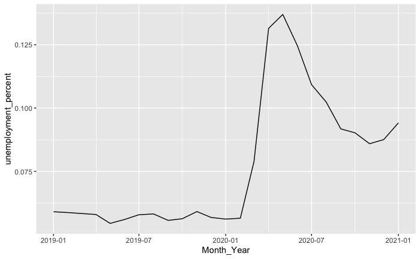

```r
library(ggplot2)

unemployment %>%
  ggplot(aes(x=Month_Year, y=unemployment_percent)) + geom_line()
```

We can see that there is a huge spike in unemployment rates and that is due to COVID. The surprising part is that unemployment rates are going back up and that is most likely due to a resurgence of COVID in Canada. Without more data that has a COVID like event it is hard to see how the unemployment rate is going to go. One interesting thing is to see if there is any correlation between COVID cases and unemployment rates.